# Stop and search in London, June 2020

Dr Matt Ashby, Jill Dando Institute of Security and Crime Science, University College London

August 2020

# Headlines

- **Police in London stopped and searched 30,517 people and vehicles in June 2020, with the number of monthly searches generally increasing over the past two years.**
- **69% of searches were for drugs, with 79% of all searches resulting in no further action.**
- **Different demographic groups are searched at different rates, with men aged 18-24 identifying as Black being 18 times more likely to be searched than the population as a whole.**

# Introduction

Stop and search is a legal power that allows police officers to search people to find out if they are carrying prohibited items such as drugs, weapons or stolen goods. Stop and search means officers can confirm if a person is or is not in possession of contraband without arresting them and taking them to a police station, but it is also a source of tension between police and communities. [A review by the College of Policing found little relationship between how many searches police do and how much crime occurs](https://whatworks.college.police.uk/Research/Documents/SS_and_crime_report.pdf), but [police insist stop and search helps them fight crime](https://www.met.police.uk/advice/advice-and-information/st-s/stop-and-search/why-we-use-stop-and-search/).

**In June 2020, police officers in London carried out 30,517 stop-and-searches**. Of those, 98% were conducted by the Metropolitan Police, 1% by British Transport Police and the remaining 1% by City of London Police. Across the three forces, 76% of stops were of pedestrians, 23% of people in vehicles and 2% of only vehicles.

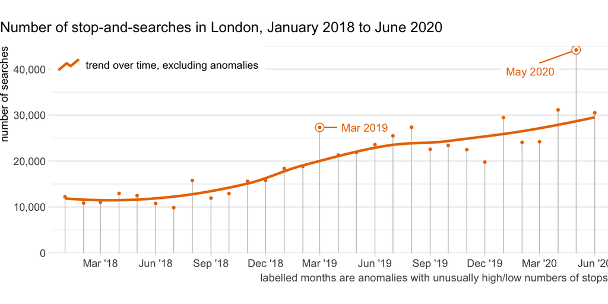

# What items are people searched for?

Police officers are empowered to search people for different items – including drugs, items to use in theft or criminal damage, stolen goods, weapons and even some fireworks – under different acts of parliament. Although police emphasise that stop and search “[protects Londoners by taking weapons off the streets](https://www.met.police.uk/police-forces/metropolitan-police/areas/about-us/about-the-met/stop-and-search/)”, only about one in six searches in June were for weapons – **69% of searches were for drugs**.

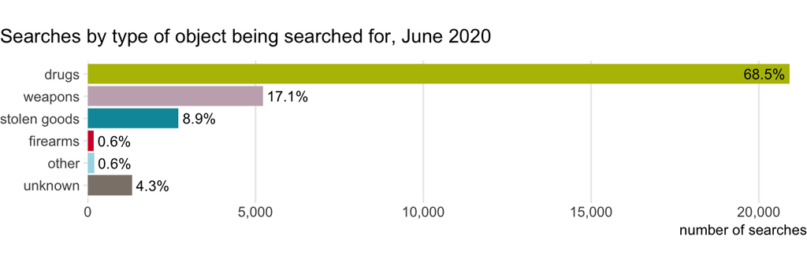

About 95% of searches are looking for the four main types of contraband: drugs, firearms, stolen goods and weapons. Since 2018, the number of searches for drugs, stolen goods and weapons have increased while searches for firearms have remained largely static.

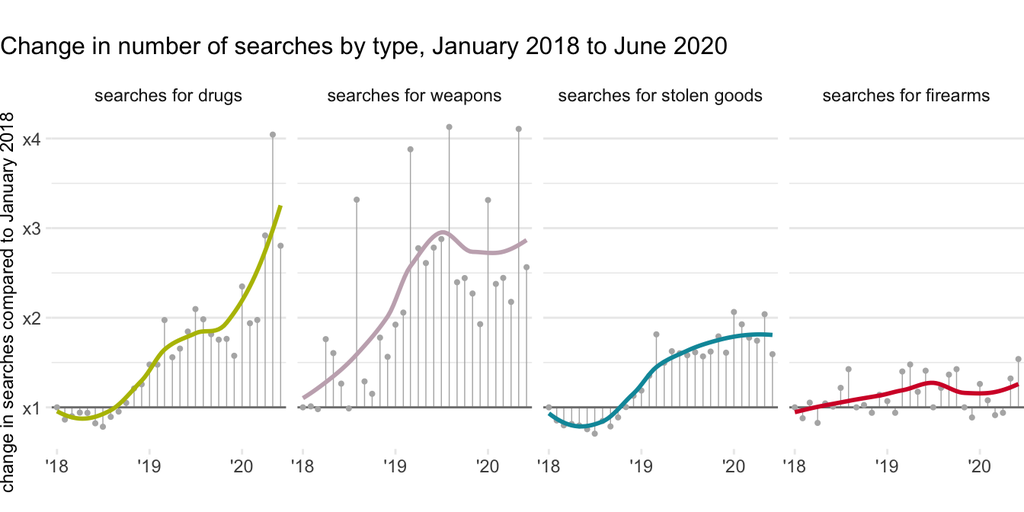

Police can search people for weapons using two different legal powers. Searches under [section 1 of the Police and Criminal Evidence Act 1984](https://www.legislation.gov.uk/ukpga/1984/60/section/1) (PACE) require the officer to have “reasonable grounds for suspecting” that the person is carrying an offensive weapon or other prohibited item. Conversely, officers can search people under section 60 of the [Criminal Justice and Public Order Act 1994](https://www.legislation.gov.uk/ukpga/1994/33/section/60) (CJPOA) without having any reason to think the person has a weapon, as long as a more-senior officer believes “incidents involving serious violence may take place” in the area. These ‘section 60’ searches are particularly controversial because they allow officers to search *anyone* in an area, even if there is no reason to think they have a weapon in their possession. In June 2020, 87% of weapons searches are based on reasonable suspicion under PACE section 1, with the remaining 13% based on authorisations under CJPOA section 60.

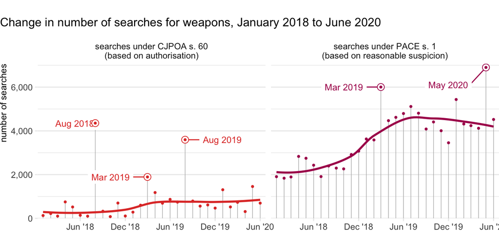

# Who do police search?

Of the 29,952 searches of pedestrians and vehicle occupants in June 2020, 93% were searches of men or boys, with 17% of people searched being aged under 18, 40% between 18 and 24, and 43% being 25 or older. The self-defined ethnicity of the person searched was known for 78% of searches, of which 43% of people described themselves as white, 30% as Black/Black British and 19% as Asian/Asian British.

**Search rates vary hugely across different groups**. While disparity between ethnic groups has generated much comment, there are also disparities betweens age groups and sexes. The best demographic predictors of a person in London being searched in June 2020 were (in descending order) being male, being aged 18-24 and being aged 10-17, with 13 groups (shown in the chart below) being searched at a higher rate than average. The reasons for these differences are likely to be complex: many types of offending are concentrated among some groups (particularly young men) as well as in some neighbourhoods, there is a [long history of racism in policing](https://www.bbc.co.uk/news/uk-47300343) and there is also an interaction between factors such as deprivation and the amount of time people spend in public (where almost-all searches occur).

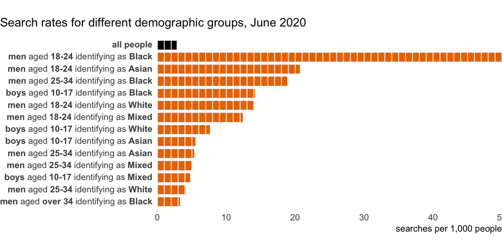

In comparison to the population as a whole, people in the group with the highest search rate (men aged 18-24 identifying as Black) are 18 times more likely to be stopped and searched. Disparities in search rates also vary according to the type of search. Disparity is highest in searches for weapons (based on reasonable suspicion), for which men aged 18-24 identifying as Black were 26 times more likely to be searched than the population at large. Of the 32 combinations of age, ethnic-group and sex categories present in the data, the rate of searches was highest for all five of the main types of search for men aged 18-24 who identified as Black.

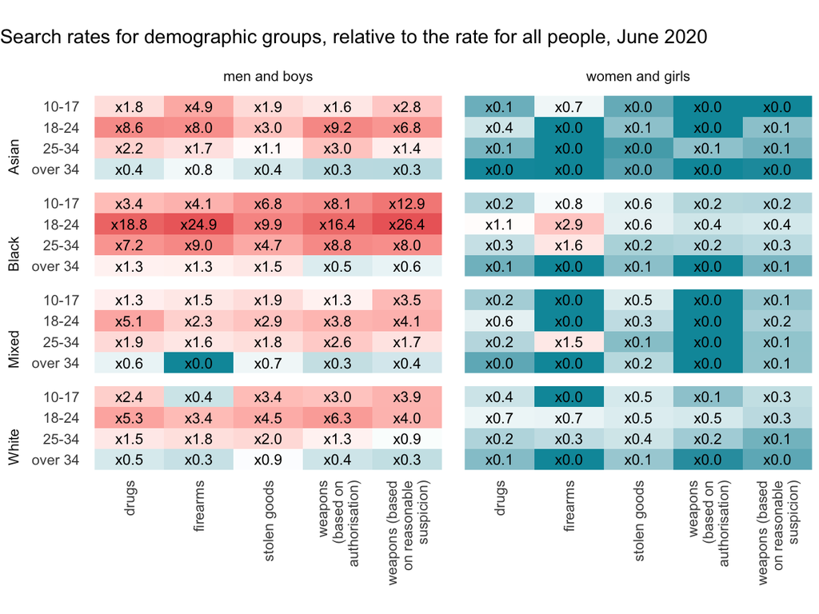

# How often to police find items during searches?

The purpose of stop and search is to “enable officers to allay or confirm suspicions about individuals without exercising their power of arrest” ([PACE Code A, paragraph 1.4](https://www.gov.uk/guidance/police-and-criminal-evidence-act-1984-pace-codes-of-practice)). As such, a search that does not find what is being searched for can be considered successful if it prevents an innocent person being arrested and a police officer being taken off the street unnecessarily. Nevertheless, all searches are an “intrusion on the liberty of the person” (PACE Code A, paragraph 1.2) and high proportions of searches that do not find anything may indicate that searches are not well targeted.

The data released by the Home Office do not specify whether or not the item police were looking for was found during a search. Instead, we can measure whether a search resulted in some formal criminal-justice process. This is not a perfect measure of whether an item was found during a search, because a person might be arrested for some other reason (for example because there was an outstanding warrant for their arrest) or contraband might be found but police deal with it informally. Nevertheless, this is the least-worst measure of search outcomes that is currently available.

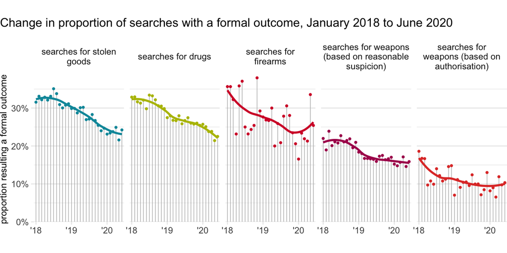

Overall, about 21% of searches in June 2020 resulted in a formal criminal-justice outcome (arrest, charge by post, caution, fixed penalty, community/local resolution or drugs warning), while the remaining **79% of searches resulted in no further action.** Over the past two years, searches for stolen goods have been most likely to lead to a formal outcome, while 89% of searches for weapons under a section 60 authorisation resulted in no further action.

In the past two years, the proportion of searches for drugs, stolen goods, weapons (based on authorisation) and weapons (based on reasonable suspicion) resulting in a formal outcome have all decreased. Overall, **the proportion of stops with a formal outcome has dropped from 28% in 2018 to 22% in the past 6 months**.

When a stop does result in formal action, the most common outcome is arrest (used in 53% of cases with a formal outcome). However, which action police choose varies with the type of search: 80% of positive searches for firearms result in arrest, compared to only 36% of positive searches for drugs. The outcomes of some searches suggest that the outcome does not relate to the type of contraband that police were looking for. For example, fixed penalties are not a legally available option for dealing with weapons or firearms offences, but 6% of searches for weapons based on reasonable suspicion, 14% of searches for weapons based on section-60 authorisations and 2% of searches for firearms resulted in fixed penalties being issued. This suggests that some weapons and firearms searches result in police not finding weapons but discovering more-minor offences such as cannabis possession.

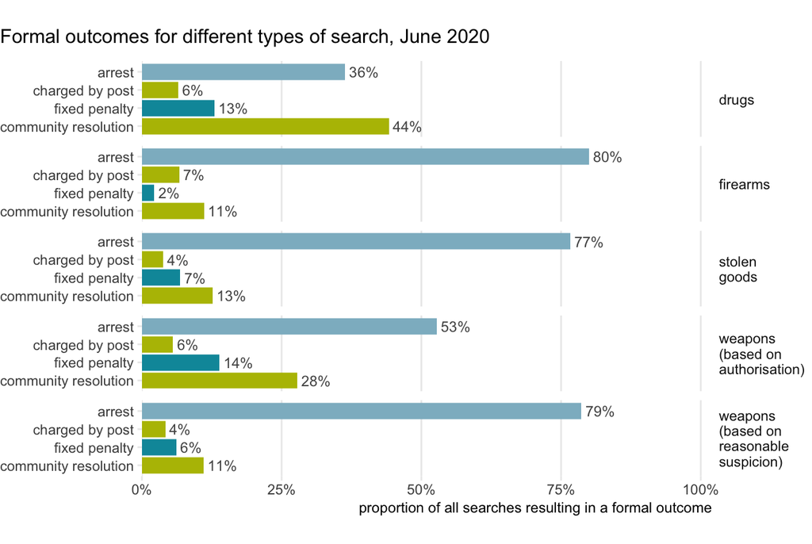

While the rate of searches varies between ethnic groups, the probability of a search resulting in a formal criminal-justice outcome is broadly the same across ethnicities – over the past six months, the probability of a formal outcome to searches of Black or Asian people was not significantly different from the probabilty of a formal outcome to searches of White people for any of the main search types.

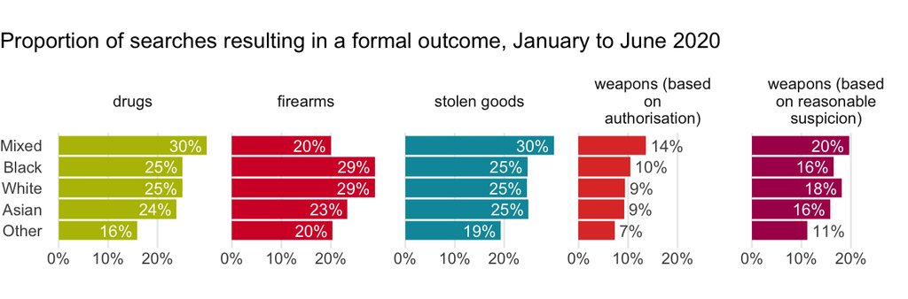

# Where do stops happen?

Stop and search is geographically concentrated in some parts of London: **half of searches in June 2020 occurred in 14% of neighbourhoods**. Searches are also concentrated in deprived areas: 69% of searches took place in neighbourhoods that were more deprived than average. In particular, 73% of searches for firearms occurred in the most-deprived half of neighbourhoods.

Of the 33 boroughs in London, the most searches in June took place in Tower Hamlets (1,829 searches), Newham (1,807) and Westminster (1,531), while the fewest took place in City of London (134 searches), Barnet (340) and Richmond upon Thames (358). By dividing London into 1,985 equally-sized cells, we can identify the places in which most stops occur:

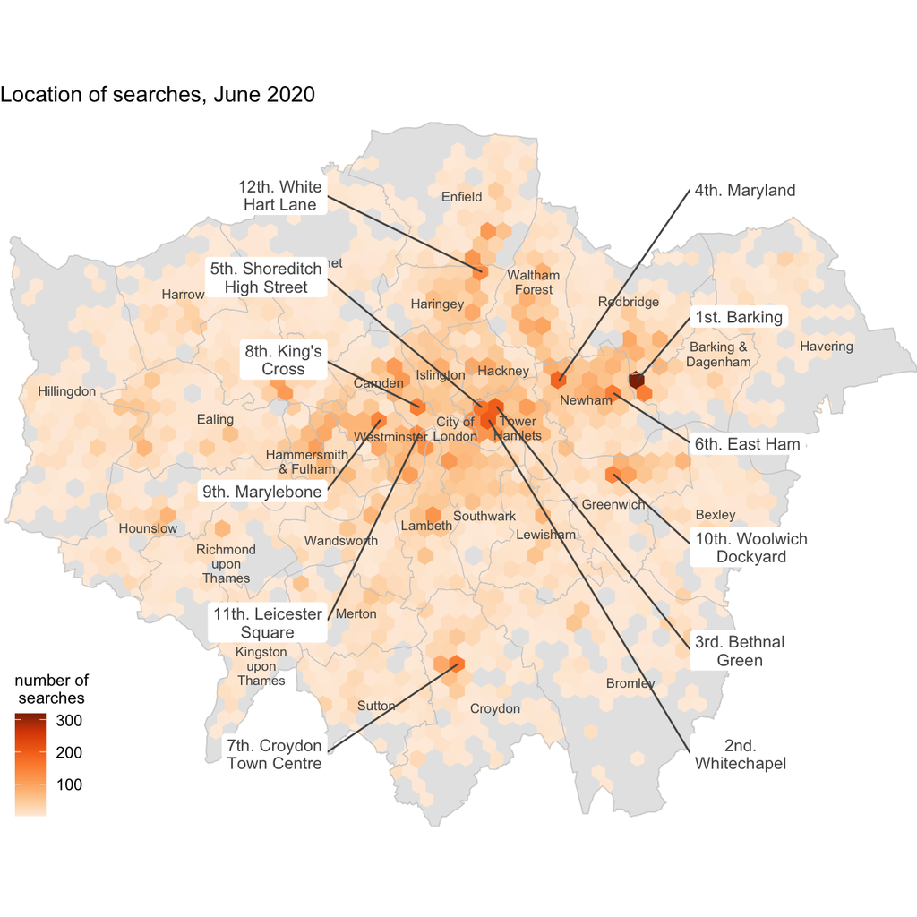

Of the 657 local-authority wards in London, the ward with the most searches in June 2020 was Abbey ward in Barking and Dagenham, in which there were more searches than in the entire boroughs of Bexley, Richmond upon Thames, Barnet and City of London.

| council ward | searches |
| --- | --- |
| Abbey, Barking and Dagenham | 395 |
| Woolwich Riverside, Greenwich | 341 |
| Stratford and New Town, Newham | 309 |
| St James’s, Westminster | 298 |
| East Ham Central, Newham | 232 |
| St Peter’s, Tower Hamlets | 228 |
| Whitechapel, Tower Hamlets | 194 |
| Broad Green, Croydon | 177 |
| Harlesden, Brent | 168 |
| West End, Westminster | 166 |

Searches for weapons under section 60 can only take place in areas in which an inspector (the third-most junior rank of the 11 ranks in the Metropolitan Police) believes “incidents involving serious violence may take place”. Of the 697 no-suspicion searches under section 60 in June 2020, more than half (55%) took place in three boroughs (24% in Barking and Dagenham, 21% in Westminster and 10% in Brent). Meanwhile, there were no section-60 searches in Enfield, Hammersmith and Fulham, Hounslow, Kingston upon Thames, Merton, Richmond upon Thames or Sutton boroughs.

# A note on data

This analysis is based on data published by the Home Office at [data.police.uk](https://data.police.uk/). The data represent all stop-and-searches recorded by police forces. Officers are legally required to record stop and searches, but some officers may not report some searches for a variety of reasons, ranging from forgetting to do so after a long shift to avoiding doing so because the search was not justified. Searches were included in this report if they were conducted by the Metropolitan Police Service or City of London Police, or by British Transport Police at a location in London. The data are published under the [Open Government Licence version 3.0](https://www.nationalarchives.gov.uk/doc/open-government-licence/version/3/).

Search rates are calculated based on [2020 estimates of the population of London by age and ethnic group](https://data.london.gov.uk/dataset/ethnic-group-population-projections) produced by the Mayor of London. Rates based on residential populations are imperfect because some people being searched in London will live outside London, but the vast majority of people searched in London are likely to also live in the region.

This report is published under a [Creative Commons Attribution Licence version 4.0](https://creativecommons.org/licenses/by/4.0/), meaning you are free to copy or redistribute this material in any medium or format, and to remix, transform, and build upon this material for any purpose, even commercially, as long as you comply with the licence terms.